# The Annotated S4

[Efficiently Modeling Long Sequences with Structured State Spaces](https://arxiv.org/abs/2111.00396)

Albert Gu, Karan Goel, and Christopher Ré.

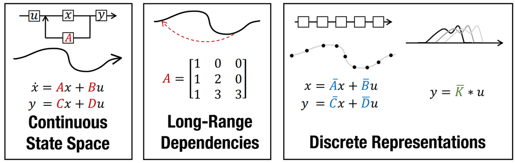

*Blog Post and [Library](https://github.com/srush/annotated-s4/) by [Sasha Rush](http://rush-nlp.com/) and [Sidd Karamcheti](https://www.siddkaramcheti.com/)*, v3

The [Structured State Space for Sequence Modeling](https://arxiv.org/abs/2111.00396) (S4) architecture is a new approach to very long-range sequence modeling tasks for vision, language, and audio, showing a capacity to capture dependencies over tens of thousands of steps. Especially impressive are the model’s results on the challenging [Long Range Arena](https://github.com/google-research/long-range-arena) benchmark, showing an ability to reason over sequences of up to **16,000+** elements with high accuracy.

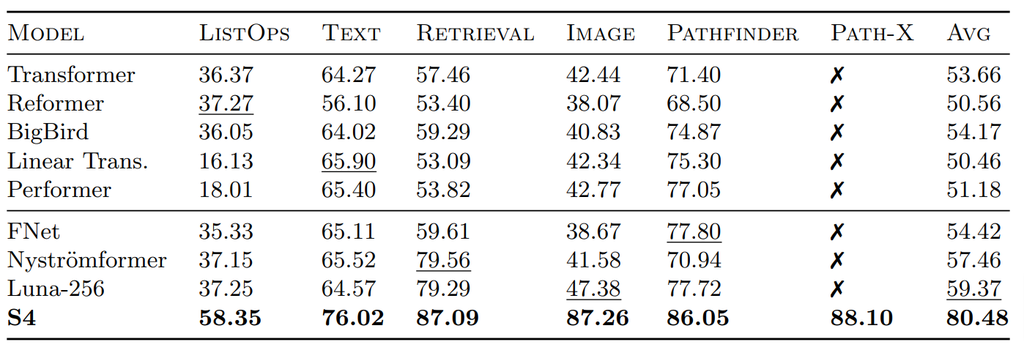

The paper is also a refreshing departure from Transformers, taking a very different approach to an important problem-space. However, several of our colleagues have also noted privately the difficulty of gaining intuition for the model. This blog post is a first step towards this goal of gaining intuition, linking concrete code implementations with explanations from the S4 paper – very much in the style of [the annotated Transformer](https://nlp.seas.harvard.edu/2018/04/03/attention.html). Hopefully this combination of code and literate explanations helps you follow the details of the model. By the end of the blog you will have an efficient working version of S4 that can operate as a CNN for training, but then convert to an efficient RNN at test time. To preview the results, you will be able to generate images from pixels and sounds directly from audio waves on a standard GPU.

[figure not shown]

[interactive chart not shown]

- Part 1: State Space Models (Modeling)
  - Discrete-time SSM: The Recurrent Representation
  - Tangent: A Mechanics Example
  - Training SSMs: The Convolutional Representation
  - An SSM Neural Network.
- Part 1b: Addressing Long-Range Dependencies with HiPPO
- Part 2: Implementing S4 (Advanced)
  - Step 1. SSM Generating Functions
  - Step 2: Diagonal Case
  - Step 3: Diagonal Plus Low-Rank
  - Diagonal Plus Low-Rank RNN.
  - Turning HiPPO to DPLR
  - Final Check
- Part 3: S4 in Practice (NN Implementation)
  - S4 CNN / RNN Layer
  - Sampling and Caching
  - Experiments: MNIST
  - Experiments: QuickDraw
  - Experiments: Spoken Digits
- Conclusion